# 10gev_muon_study

10 GeV vertical-muon response of the MuonSLab plastic-scintillator stack, from a 1,000-muon run (2026-07-22). Each event is a 10 GeV μ⁻ fired through the slab centre, straight down through the four layers. The notebook reports the energy loss per layer and the photoelectron yield of every SiPM channel — means ± RMS over the 1,000 muons, plus the per-channel NPE distributions. Geant4 11.4.2 + ROOT.

Note: the SiPMs are modelled at 10 × 10 mm (1 cm²), larger than a real 3×3 / 6×6 mm device, so the photoelectron numbers below are inflated accordingly (details at the end).

## 1. Setup & geometry

Four slabs of EJ-200-type plastic (10 000 γ/MeV, Birks k = 0.126 mm/MeV, n = 1.58), each 20 × 20 × 2 cm, wrapped in ESR + tape and read out by 12 SiPMs per slab (three on each ±X / ±Y face, 48 channels total), air-coupled. Three slabs cluster at z ≈ 42 / 64 / 86 mm; the fourth sits at z ≈ −118 mm below an aluminium battery box.

```python
%matplotlib inline
import glob, numpy as np, pandas as pd, matplotlib.pyplot as plt, uproot, collections
plt.rcParams.update({"font.size": 10, "axes.grid": True, "grid.alpha": 0.3, "figure.dpi": 110})
FILES = sorted(glob.glob("../slabsimu_template/build/out_c*.root"))   # 4 chunks x 250 muons

def gather(key):
    out = []
    for fn in FILES:
        out.extend(list(uproot.open(fn)["Simu"].arrays([key], library="np")[key]))
    return out

vid, ed, det = gather("VoxelID"), gather("VoxelEdep"), gather("SiPM_OldHit_Det_ID")
N = len(vid)
pz = float(np.array(uproot.open(FILES[0])["Simu"].arrays(["muon_pz"], library="np")["muon_pz"])[0][0])
print(f"{N} muons loaded  (|pz| = {abs(pz):.0f} MeV = 10 GeV, downward)  from {len(FILES)} chunk files")
```

```
1000 muons loaded  (|pz| = 10000 MeV = 10 GeV, downward)  from 4 chunk files
```

## 2. Energy loss per layer

Every muon crosses all four layers. The mean dE/dx sits above the most-probable value because of the Landau high-energy-loss tail (thin-slab regime). Layer 4 — the slab below the aluminium battery box — has a higher mean and larger RMS from delta-ray / shower contamination produced in the ~13 cm of aluminium above it.

```python
led = {k: np.zeros(N) for k in range(4)}
for i, (vs, es) in enumerate(zip(vid, ed)):
    pe = collections.defaultdict(float)
    for v, e in zip(vs, es):
        pe[int(v)] += float(e)
    for k in range(4):
        led[k][i] = pe.get(k, 0.0)
order, zpos = [3, 2, 1, 0], {3: "≈86 mm (top)", 2: "≈64 mm", 1: "≈42 mm", 0: "≈-118 mm (bottom)"}
tot = np.array([sum(led[k][i] for k in range(4)) for i in range(N)])
pd.DataFrame({
    "Layer": ["L1 (top)", "L2", "L3", "L4 (bottom)"],
    "VoxelID": order,
    "z": [zpos[k] for k in order],
    "Edep mean [MeV]": [round(led[k].mean(), 3) for k in order],
    "RMS [MeV]": [round(led[k].std(), 3) for k in order],
    "dE/dx [MeV/cm]": [round(led[k].mean() / 2.0, 3) for k in order],
})
```

|  | Layer | VoxelID | z | Edep mean [MeV] | RMS [MeV] | dE/dx [MeV/cm] |
| --- | --- | --- | --- | --- | --- | --- |
| 0 | L1 (top) | 3 | ≈86 mm (top) | 4.003 | 0.975 | 2.001 |
| 1 | L2 | 2 | ≈64 mm | 4.247 | 1.476 | 2.123 |
| 2 | L3 | 1 | ≈42 mm | 4.228 | 1.458 | 2.114 |
| 3 | L4 (bottom) | 0 | ≈-118 mm (bottom) | 4.624 | 2.570 | 2.312 |

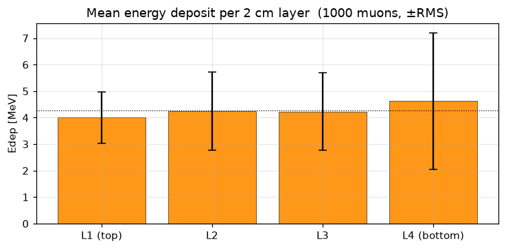

```python
fig, ax = plt.subplots(figsize=(6.8, 3.4))
ax.bar(range(4), [led[k].mean() for k in order],
       yerr=[led[k].std() for k in order], color="darkorange", capsize=4, edgecolor="k", lw=0.4, alpha=0.9)
ax.axhline(tot.mean() / 4, color="k", ls=":", lw=0.8)
ax.set_xticks(range(4)); ax.set_xticklabels(["L1 (top)", "L2", "L3", "L4 (bottom)"])
ax.set_ylabel("Edep [MeV]"); ax.set_title(f"Mean energy deposit per 2 cm layer  ({N} muons, ±RMS)")
plt.tight_layout(); plt.show()
```

## 3. Light yield per SiPM

```python
sp = {d: np.zeros(N) for d in range(48)}
for i, ds in enumerate(det):
    c = collections.Counter(int(x) for x in ds)
    for d in range(48):
        sp[d][i] = c.get(d, 0)
per_mu = np.array([sum(sp[d][i] for d in range(48)) for i in range(N)])
slab_pe = {s: sum(sp[f * 4 + s].mean() for f in range(12)) for s in range(4)}
print(f"per-muon total: {per_mu.mean():.1f} ± {per_mu.std():.1f} p.e.   "
      f"({per_mu.mean()/tot.mean():.1f} p.e./MeV overall)")
pd.DataFrame({
    "Layer": ["L1 (top)", "L2", "L3", "L4 (bottom)"],
    "p.e./μ (12 SiPMs)": [round(slab_pe[s], 2) for s in [3, 2, 1, 0]],
    "Edep mean [MeV]": [round(led[s].mean(), 3) for s in [3, 2, 1, 0]],
    "p.e./MeV": [round(slab_pe[s] / led[s].mean(), 2) for s in [3, 2, 1, 0]],
})
```

```
per-muon total: 235.7 ± 56.4 p.e.   (13.8 p.e./MeV overall)
```

|  | Layer | p.e./μ (12 SiPMs) | Edep mean [MeV] | p.e./MeV |
| --- | --- | --- | --- | --- |
| 0 | L1 (top) | 55.65 | 4.003 | 13.90 |
| 1 | L2 | 58.45 | 4.247 | 13.76 |
| 2 | L3 | 58.07 | 4.228 | 13.73 |
| 3 | L4 (bottom) | 63.56 | 4.624 | 13.74 |

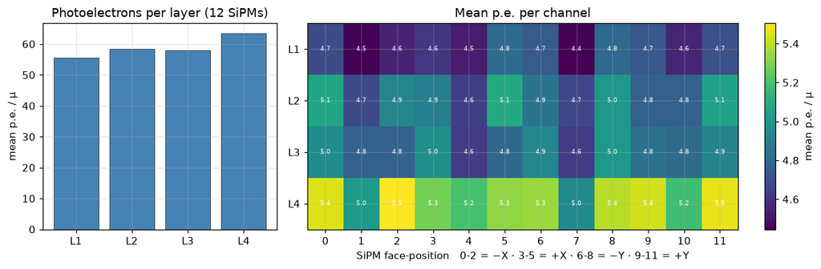

```python
mat = np.array([[sp[f * 4 + s].mean() for f in range(12)] for s in [3, 2, 1, 0]])
fig, (a1, a2) = plt.subplots(1, 2, figsize=(11.5, 3.7), gridspec_kw={"width_ratios": [1, 2.3]})
a1.bar(["L1", "L2", "L3", "L4"], mat.sum(axis=1), color="steelblue", edgecolor="k", lw=0.4)
a1.set_ylabel("mean p.e. / μ"); a1.set_title("Photoelectrons per layer (12 SiPMs)")
im = a2.imshow(mat, aspect="auto", cmap="viridis")
a2.set_xticks(range(12)); a2.set_yticks(range(4)); a2.set_yticklabels(["L1", "L2", "L3", "L4"])
a2.set_xlabel("SiPM face-position   0-2 = −X · 3-5 = +X · 6-8 = −Y · 9-11 = +Y")
a2.set_title("Mean p.e. per channel")
for r in range(4):
    for c in range(12):
        a2.text(c, r, f"{mat[r, c]:.1f}", ha="center", va="center", color="w", fontsize=6)
plt.colorbar(im, ax=a2, label="mean p.e. / μ"); plt.tight_layout(); plt.show()
```

## 4. NPE distribution per SiPM (all 48 channels)

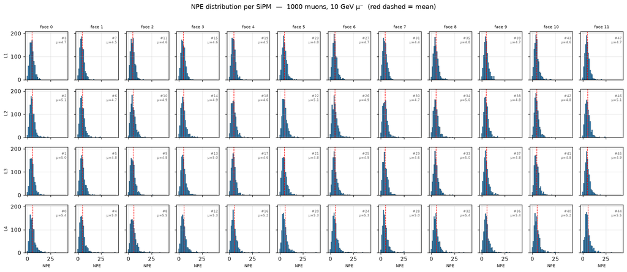

```python
fig, axes = plt.subplots(4, 12, figsize=(16, 7), sharex=True, sharey=True)
maxpe = max(int(sp[d].max()) for d in range(48))
bins = np.arange(-0.5, maxpe + 2, 1)
for row, slab in enumerate([3, 2, 1, 0]):
    for fpos in range(12):
        ax = axes[row, fpos]; did = fpos * 4 + slab; data = sp[did]
        ax.hist(data, bins=bins, color="C0", alpha=0.85, edgecolor="k", lw=0.3)
        ax.axvline(data.mean(), color="r", ls="--", lw=0.9)
        ax.text(0.97, 0.90, f"#{did}\nμ={data.mean():.1f}", transform=ax.transAxes,
                ha="right", va="top", fontsize=6.2, color="dimgray")
        if row == 0:
            ax.set_title(f"face {fpos}", fontsize=7)
        if fpos == 0:
            ax.set_ylabel(["L1", "L2", "L3", "L4"][row], fontsize=8)
        if row == 3:
            ax.set_xlabel("NPE", fontsize=7)
fig.suptitle(f"NPE distribution per SiPM  —  {N} muons, 10 GeV μ⁻  (red dashed = mean)",
             fontsize=12)
plt.tight_layout(rect=[0, 0, 1, 0.97]); plt.show()
```

## 6. Caveats & reproduce

The SiPM active area is 10 × 10 mm in this model (`config.yaml` `SiPM.x_length = y_length = 1.0 cm`), not a realistic device size — re-run with 3×3 or 6×6 mm before quoting absolute photoelectron yields, since they scale with active area. The SiPMs are also air-coupled (no optical grease), giving a low ~0.14 % light collection. The template was ported from Geant4 10.6 to 11.4; the scintillation yield was verified (G4-11 renamed `FASTCOMPONENT` → `SCINTILLATIONCOMPONENT1`, which had silently produced zero scintillation light before the fix).

The 1,000 muons were run as four parallel chunks (`out_c0..c3.root`); this notebook aggregates all four.